## 2.4 Theoretical

3 a)

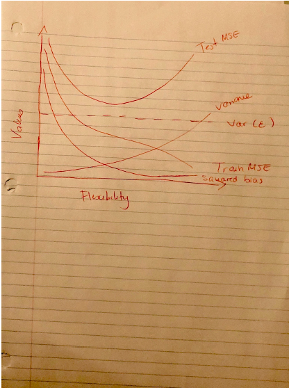

Sketch of variance, bias, train/test MSE, and irreducible error curves based on flexibility

2. As seen with the bias-variance trade off, as flexibility increases, there is an increase in variance but bias will decrease. By the same token, decrease in flexibility means higher bias but lower variance. These two quantities help determine the overall outcome of the Test MSE, meaning that a poor combination of these hinders test results. This is what we see happening when flexibility increases too much and the training data might have gotten over trained. We also know that the test MSE can also never be below irreducible error, which is a constant. Additionally, other than the fact that training MSE is usually less than testing MSE in general, training MSE also improves as flexibility increases since the curve is able to create a closer fit to the data. However, it is most likely memorizing the training data as we get a closer fit.

7 a)

Test Point = X1 = X2 = X3 = 0. Observation 1 vs. Test: = sqrt((0-0)^2 + (3-0)^2 + (0-0)^2) = 3

Observation 2 vs. Test: = sqrt((2-0)^2 + (0-0)^2 + (0-0)^2) = 2

Observation 3 vs. Test: = sqrt((0-0)^2 + (1-0)^2 + (3-0)^2) = sqrt(10) = approx 3.16

Observation 4 vs. Test: = sqrt((0-0)^2 + (1-0)^2 + (2-0)^2) = sqrt(5) = approx 2.24

Observation 5 vs. Test: = sqrt((-1-0)^2 + (0-0)^2 + (1-0)^2) = approx 1.41

Observation 6 vs. Test: = sqrt((1-0)^2 + (1-0)^2 + (1-0)^2) = approx 1.73

2. KNN where K = 1 The 1-NN to (0,0,0) is (-1, 0, 1) - observation 5. Observation 5 response is Green, therefore, our prediction will be Green.
3. KNN where K = 3

The 3-NN to (0,0,0) are: - Observation 5 (-1,0,1) - Green - Observation 6 (1, 1, 1) - Red - Obsevation 2 (2, 0, 0) - Red

which is 2/3 to Red, therefore, our prediction will be Red.

## 2.4 Applied

8 a & b) College data set

```r
input_file <- "College.csv"
college <- read.csv(input_file, header = TRUE)
rownames(college) <- college[,1]
college <- college[,-1]
```

3. i & ii

```r
summary(college)
```

```
##  Private        Apps           Accept          Enroll       Top10perc
##  No :212   Min.   :   81   Min.   :   72   Min.   :  35   Min.   : 1.00
##  Yes:565   1st Qu.:  776   1st Qu.:  604   1st Qu.: 242   1st Qu.:15.00
##            Median : 1558   Median : 1110   Median : 434   Median :23.00
##            Mean   : 3002   Mean   : 2019   Mean   : 780   Mean   :27.56
##            3rd Qu.: 3624   3rd Qu.: 2424   3rd Qu.: 902   3rd Qu.:35.00
##            Max.   :48094   Max.   :26330   Max.   :6392   Max.   :96.00
##    Top25perc      F.Undergrad     P.Undergrad         Outstate
##  Min.   :  9.0   Min.   :  139   Min.   :    1.0   Min.   : 2340
##  1st Qu.: 41.0   1st Qu.:  992   1st Qu.:   95.0   1st Qu.: 7320
##  Median : 54.0   Median : 1707   Median :  353.0   Median : 9990
##  Mean   : 55.8   Mean   : 3700   Mean   :  855.3   Mean   :10441
##  3rd Qu.: 69.0   3rd Qu.: 4005   3rd Qu.:  967.0   3rd Qu.:12925
##  Max.   :100.0   Max.   :31643   Max.   :21836.0   Max.   :21700
##    Room.Board       Books           Personal         PhD
##  Min.   :1780   Min.   :  96.0   Min.   : 250   Min.   :  8.00
##  1st Qu.:3597   1st Qu.: 470.0   1st Qu.: 850   1st Qu.: 62.00
##  Median :4200   Median : 500.0   Median :1200   Median : 75.00
##  Mean   :4358   Mean   : 549.4   Mean   :1341   Mean   : 72.66
##  3rd Qu.:5050   3rd Qu.: 600.0   3rd Qu.:1700   3rd Qu.: 85.00
##  Max.   :8124   Max.   :2340.0   Max.   :6800   Max.   :103.00
##     Terminal       S.F.Ratio      perc.alumni        Expend
##  Min.   : 24.0   Min.   : 2.50   Min.   : 0.00   Min.   : 3186
##  1st Qu.: 71.0   1st Qu.:11.50   1st Qu.:13.00   1st Qu.: 6751
##  Median : 82.0   Median :13.60   Median :21.00   Median : 8377
##  Mean   : 79.7   Mean   :14.09   Mean   :22.74   Mean   : 9660
##  3rd Qu.: 92.0   3rd Qu.:16.50   3rd Qu.:31.00   3rd Qu.:10830
##  Max.   :100.0   Max.   :39.80   Max.   :64.00   Max.   :56233
##    Grad.Rate
##  Min.   : 10.00
##  1st Qu.: 53.00
##  Median : 65.00
##  Mean   : 65.46
##  3rd Qu.: 78.00
##  Max.   :118.00
```

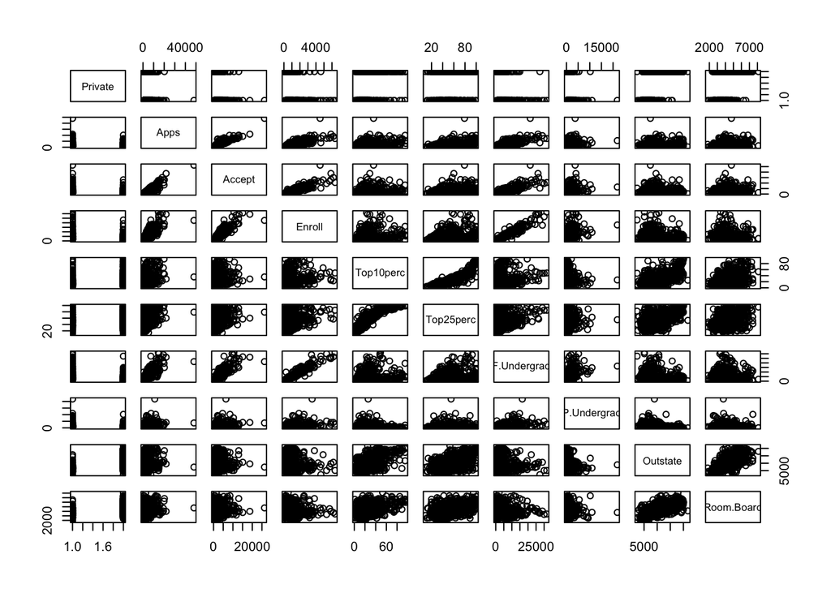

```r
# a scatterplot for every pair of variables for any given dataset
pairs(college[,1:10])
```

## Plot Outstate vs. Private

3. iii

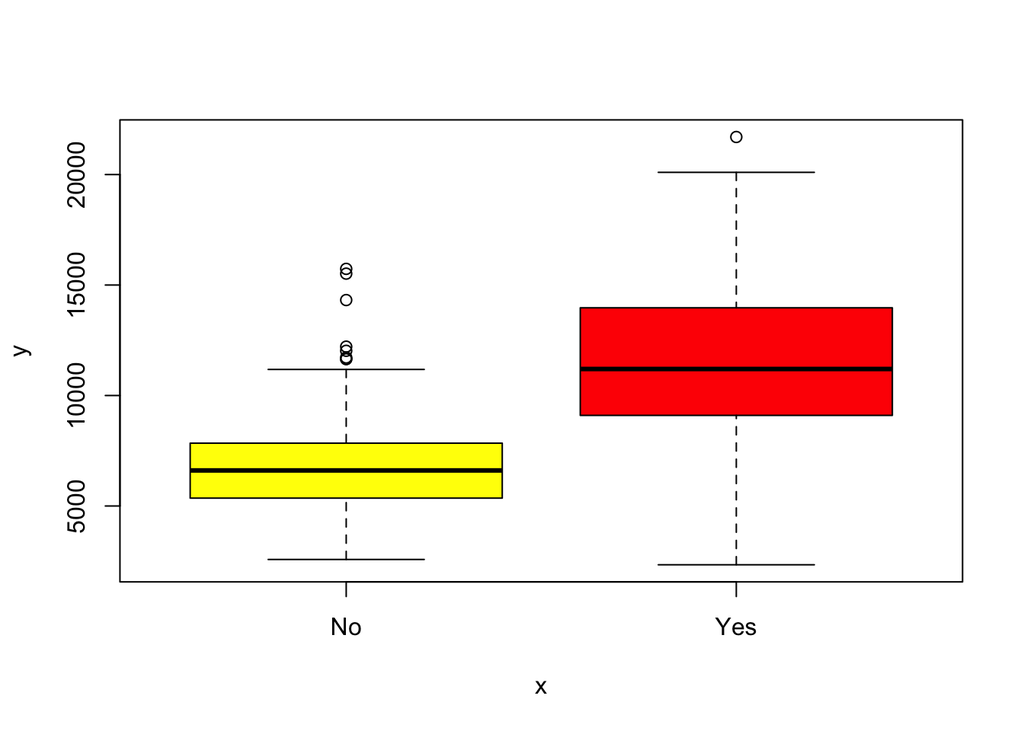

```r
plot(college$Private, college$Outstate, col = c("yellow", "red"))
```

## Plot Outstate vs. Elite

3. iv

```r
# qualitative variable called Elite, by binning Top10perc variable
Elite <- rep("No", nrow(college))
Elite[college$Top10perc > 50] = "Yes"
Elite <- as.factor(Elite)
college <- data.frame(college, Elite)

# summarize the elite universities
summary(college$Elite)
```

```
##  No Yes
## 699  78
```

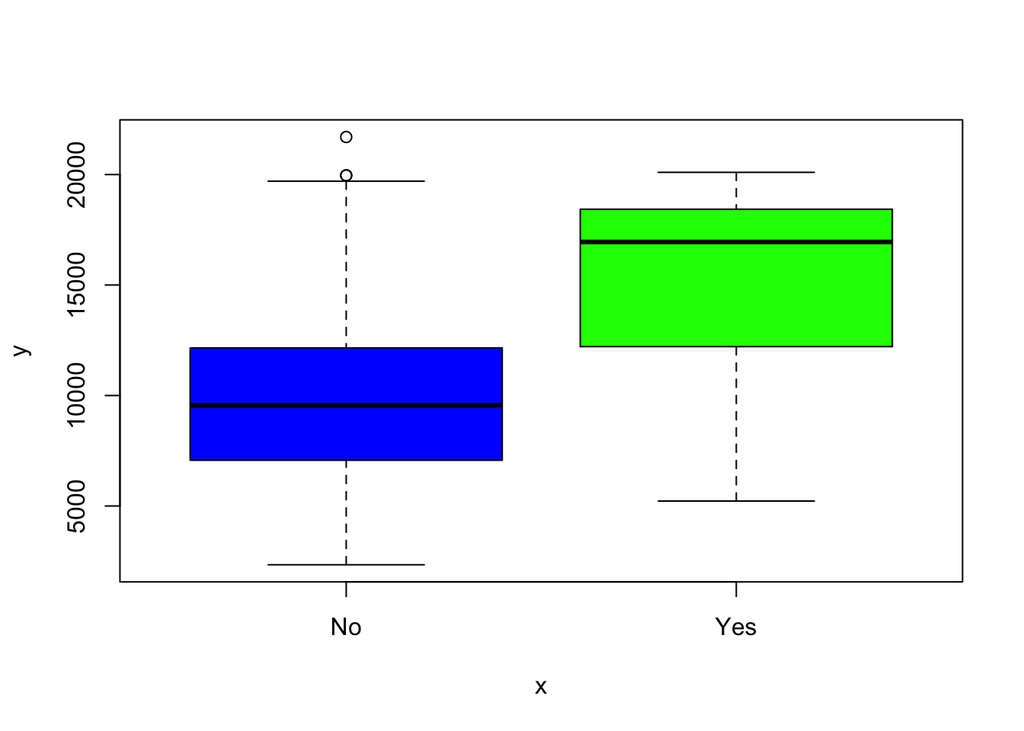

```r
# plot
plot(college$Elite, college$Outstate, col = c("blue", "green"))
```

3. v

Use hist() to produce histograms instead

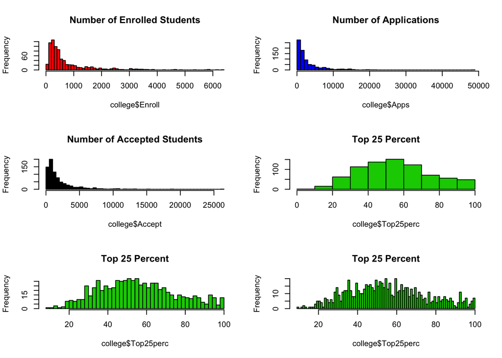

```r
# divide print window into 4
par(mfrow = c(3,2))
# produce histograms for some of the quantitative variables
hist(college$Enroll, main = "Number of Enrolled Students", col = 2, breaks = 50)
hist(college$Apps, main = "Number of Applications", col = 4, breaks = 50 )
hist(college$Accept, main = "Number of Accepted Students", col = 1, breaks = 50)
# different bins for same quantitative variable
hist(college$Top25perc, main = "Top 25 Percent", col = 3, breaks = 10)
hist(college$Top25perc, main = "Top 25 Percent", col = 3, breaks = 50)
hist(college$Top25perc, main = "Top 25 Percent", col = 3, breaks = 100)
```

3. vi

Further exploration of data

```r
college[college$PhD > 100,]
```

```
##                                   Private Apps Accept Enroll Top10perc
## Texas A&M University at Galveston      No  529    481    243        22
##                                   Top25perc F.Undergrad P.Undergrad Outstate
## Texas A&M University at Galveston        47        1206         134     4860
##                                   Room.Board Books Personal PhD Terminal
## Texas A&M University at Galveston       3122   600      650 103       88
##                                   S.F.Ratio perc.alumni Expend Grad.Rate Elite
## Texas A&M University at Galveston      17.4          16   6415        43    No
```

```r
summary(college$Accept)
```

```
##    Min. 1st Qu.  Median    Mean 3rd Qu.    Max.
##      72     604    1110    2019    2424   26330
```

9. Auto data set

```r
auto_input_file <- "Auto.csv"
auto <- read.csv(auto_input_file, header = TRUE)
# remove missing value from data
auto <- na.omit(auto)
# a) print quantitative and qualitative predictors -  should be all quantitative except the name predictor
sapply(auto, class)
```

```
##          mpg    cylinders displacement   horsepower       weight acceleration
##    "numeric"    "integer"    "numeric"    "integer"    "integer"    "numeric"
##         year       origin         name
##    "integer"    "integer"     "factor"
```

```r
auto$origin <- as.factor(auto$origin)
```

Since R stores categorical variables as factors, the name predictor is qualitative, while all the other predictors are quantitative. Since origin is a multi-valued class that only seems to take on 3 values (1,2,3), this could be treated as categorical, as well.

```r
# b) range of each quantitative predictor

# filter out the qualtitative predictors
quant_preds <- auto[sapply(auto, is.factor) == FALSE]

# apply range to the quantitative predictors
sapply(quant_preds, range)
```

```
##       mpg cylinders displacement horsepower weight acceleration year
## [1,]  9.0         3           68         46   1613          8.0   70
## [2,] 46.6         8          455        230   5140         24.8   82
```

```r
# c) get the mean and standard deviation of each quantitative predictor
sapply(quant_preds, function(x){c(mean(x), sd(x))})
```

```
##            mpg cylinders displacement horsepower    weight acceleration
## [1,] 23.445918  5.471939      194.412  104.46939 2977.5842    15.541327
## [2,]  7.805007  1.705783      104.644   38.49116  849.4026     2.758864
##           year
## [1,] 75.979592
## [2,]  3.683737
```

```r
# d) remove the 10th through 85th observations. find the range, mean, and standard deviation of each predictor in the subset of the data that remains
quant_preds <- quant_preds[-(10:85),]
sapply(quant_preds, function(x){c(mean(x), sd(x))})
```

```
##            mpg cylinders displacement horsepower    weight acceleration
## [1,] 24.404430  5.373418    187.24051  100.72152 2935.9715    15.726899
## [2,]  7.867283  1.654179     99.67837   35.70885  811.3002     2.693721
##           year
## [1,] 77.145570
## [2,]  3.106217
```

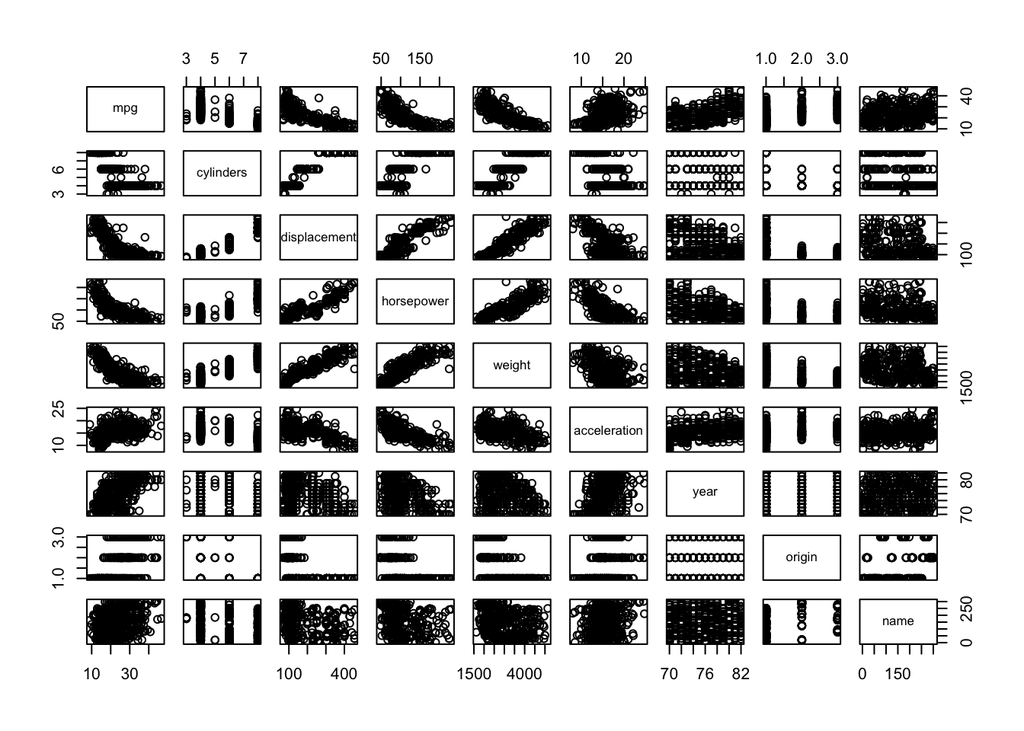

```r
# e) Using the full data set, investigate the predictors graphically, using scatterplots or other tools of your choice. Create some plots highlighting the relationships among the predictors.
pairs(auto)
```

```r
# f) Suppose that we wish to predict gas mileage (mpg) on the basis of the other variables. Do your plots suggest that any of the other variables might be useful in predicting mpg?
cor(quant_preds[-1], quant_preds$mpg)
```

```
##                    [,1]
## cylinders    -0.7640731
## displacement -0.7970694
## horsepower   -0.7650215
## weight       -0.8324767
## acceleration  0.3767761
## year          0.6133429
```

For example, positive relation between mpg and year. 10) Boston data set

```r
# a) load boston data set - how many rows / columns
boston_input_file <- "Boston.csv"
boston <- read.csv(boston_input_file, header = TRUE)
dim(boston) # rows and columns
```

```
## [1] 506  15
```

The rows represent the observations (n), while the columns represent the variables (predictors).

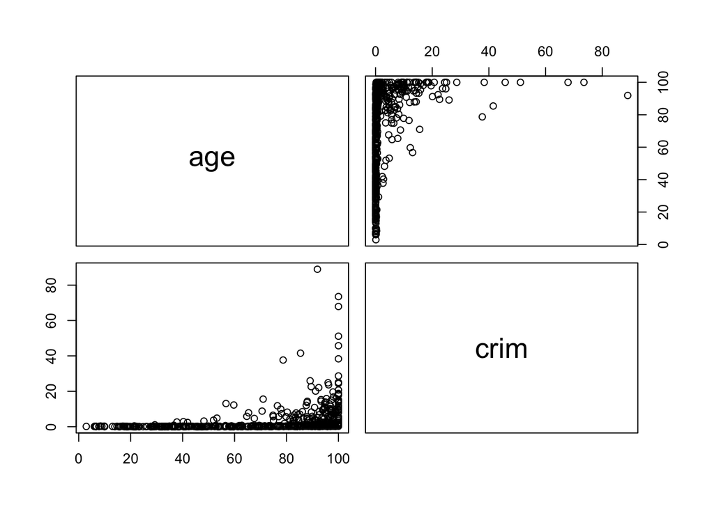

```r
# b) some pairwise plots
pairs(~ age + crim, data = boston)
```

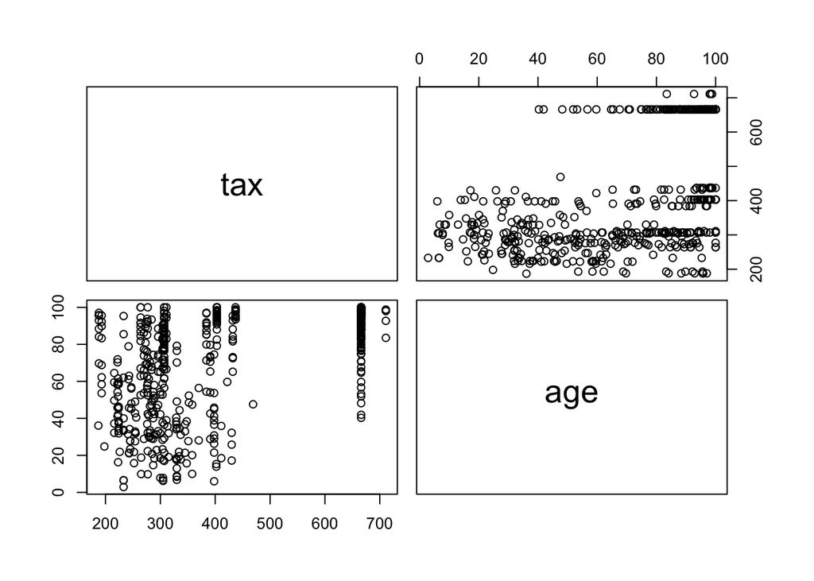

```r
pairs(~ tax + age, data = boston)
```

```r
# c)
associations <- cor(boston$crim, boston)
associations
```

```
##              X crim         zn     indus        chas       nox         rm
## [1,] 0.4074072    1 -0.2004692 0.4065834 -0.05589158 0.4209717 -0.2192467
##            age        dis       rad       tax   ptratio      black     lstat
## [1,] 0.3527343 -0.3796701 0.6255051 0.5827643 0.2899456 -0.3850639 0.4556215
##            medv
## [1,] -0.3883046
```

This tells you that there is an association between other predictors. For example, some of the associated predictors are rad, tax, lstat, etc.

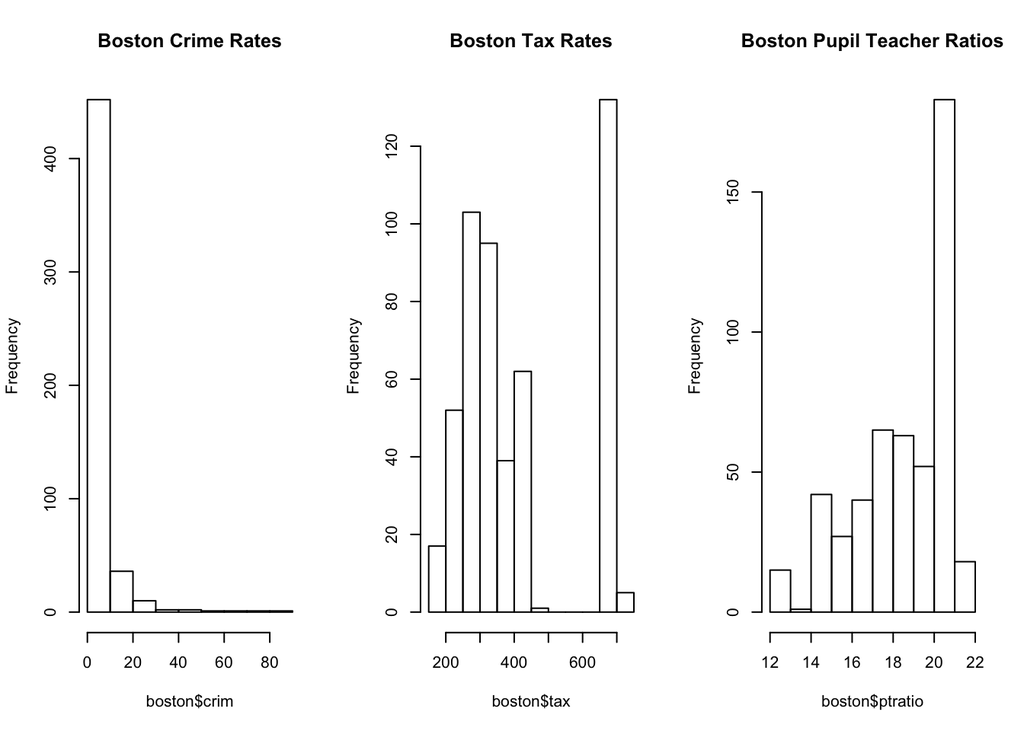

```r
# d) Do any of the suburbs of Boston appear to have particularly high crime rates? Tax rates? Pupil-teacher ratios? Comment on the range of each predictor
par(mfrow = c(1,3))
# crime rates
hist(boston$crim, main = "Boston Crime Rates", breaks = 10)

# tax rates
hist(boston$tax, main = "Boston Tax Rates", breaks = 10)

# pupil teacher ratios
hist(boston$ptratio, main = "Boston Pupil Teacher Ratios", breaks = 10)
```

Comment on the range of the predictors

```r
# e) How many of the suburbs in this data set bound the Charles river?
charles <- table(boston$chas)
sprintf("There are %d suburbs that bound Charles river", charles[2:2])
```

```
## [1] "There are 35 suburbs that bound Charles river"
```

```r
# f) What is the median pupil-teacher ratio among the towns in this data set?
paste0("Median for pupil teacher ratio is ", median(boston$ptratio))
```

```
## [1] "Median for pupil teacher ratio is 19.05"
```

```r
# g) Which suburb of Boston has lowest median value of owneroccupied homes? What are the values of the other predictors for that suburb, and how do those values compare to the overall ranges for those predictors?

lw_median <- which.min(boston$medv)
paste0("The lowest median value is suburb  ", lw_median)
```

```
## [1] "The lowest median value is suburb  399"
```

```r
boston[lw_median,]
```

```
##       X    crim zn indus chas   nox    rm age    dis rad tax ptratio black
## 399 399 38.3518  0  18.1    0 0.693 5.453 100 1.4896  24 666    20.2 396.9
##     lstat medv
## 399 30.59    5
```

```r
# h) In this data set, how many of the suburbs average more than seven rooms per dwelling? More than eight rooms per dwelling? Comment on the suburbs that average more than eight rooms per dwelling.

# more than 7 rooms per dwelling
calculate_rooms <- function(rooms){
  houses <- table(boston$rm > rooms)[2:2]
  return(houses)
}
sprintf("There are %d houses with more than 7", calculate_rooms(7))
```

```
## [1] "There are 64 houses with more than 7"
```

```r
# more than 8 rooms per dwelling
sprintf("There are %d houses with more than 8", calculate_rooms(8))
```

```
## [1] "There are 13 houses with more than 8"
```

## 3.7 Theoretical

1. 3. For a fixed value of IQ and GPA, males earn more on average than females provided that the GPA is high enough. β0 = 50, ˆβ1 = 20, ˆβ2 = 0.07, ˆβ3 = 35, ˆβ4 = 0.01, ˆβ5 = −10. X1 = GPA, X2 = IQ, X3 = Gender (1 for Female and 0 for Male), X4 = Interaction between GPA and IQ, and X5 = Interaction between GPA and Gender. Gender: Female = 1, Male = 0 Y(female) = 50 + 20GPA + 0.07IQ + 35GENDER + 0.01(GPA x IQ) - 10(GPA x GENDER) = 85 + 20GPA + 0.07IQ + 0.01(GPA x IQ) - 10 (GPA)

Y(male) = 50 + 20GPA + 0.07IQ + 0.01(GPA x IQ)

2. Salary (female), IQ = 110, GPA = 4.0 Salary(female) = 85 + 20(4) + 0.07(110) + 0.01(4*110) - 10(4) = 137.1 or $137100
3. False. The p-values help determine the synergy.
1. Cubic regression is more flexible but it may just introduce additional noise and cause over fitting, meaning that the RSS for cubic training data may be lower than linear. However, in reality, linear regression is probably better since the true relation is linear.
2. Linear regression RSS will be lower on test since the true relation is linear.
3. Cubic regression RSS will still be lower on train.
4. Since the true relation is not linear, it is possible that the cubic regression will have a lower RSS. However, since we do not know the true degree, the results depend on how far the true relationship is from linear regression and cubic regression. For example, if the true relation is closer to linear, then linear will be lower.

## 3.7 Applied

```r
# a) Use the lm() function to perform a simple linear regression with mpg as the response and horsepower as the predictor.
lm.fit.auto <- lm(mpg ~ horsepower, data = auto)
summary(lm.fit.auto)
```

```
##
## Call:
## lm(formula = mpg ~ horsepower, data = auto)
##
## Residuals:
##      Min       1Q   Median       3Q      Max
## -13.5710  -3.2592  -0.3435   2.7630  16.9240
##
## Coefficients:
##              Estimate Std. Error t value Pr(>|t|)
## (Intercept) 39.935861   0.717499   55.66   <2e-16 ***
## horsepower  -0.157845   0.006446  -24.49   <2e-16 ***
## ---
## Signif. codes:  0 '***' 0.001 '**' 0.01 '*' 0.05 '.' 0.1 ' ' 1
##
## Residual standard error: 4.906 on 390 degrees of freedom
## Multiple R-squared:  0.6059, Adjusted R-squared:  0.6049
## F-statistic: 599.7 on 1 and 390 DF,  p-value: < 2.2e-16
```

1. Is there a relationship between the predictor and the response? Yes there is a relationship between the predictor and response, as seen by low p-value.
2. How strong is the relationship between the predictor and the response? The R-squared value is approximately 61%, which shows that a big part of the variability in mpg is attributed to (explained through) the horsepower predictor.
3. Is the relationship between the predictor and the response positive or negative? Negative relationship.
4. What is the predicted mpg associated with a horsepower of 98? What are the associated 95% confidence and prediction intervals?

```r
# confidence intervals

predict(lm.fit.auto, data.frame(horsepower = 98), interval = "confidence")
```

```
##        fit      lwr      upr
## 1 24.46708 23.97308 24.96108
```

```r
# prediction intervals
predict(lm.fit.auto, data.frame(horsepower = 98), interval = "prediction")
```

```
##        fit     lwr      upr
## 1 24.46708 14.8094 34.12476
```

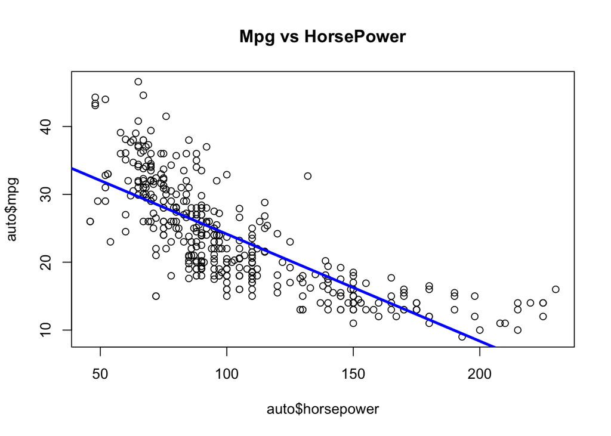

```r
# plot response and predictor
plot(auto$horsepower, auto$mpg, main = "Mpg vs HorsePower")

# least squares regression line
abline(lm.fit.auto, lwd = 3,  col = "blue")
```

c)

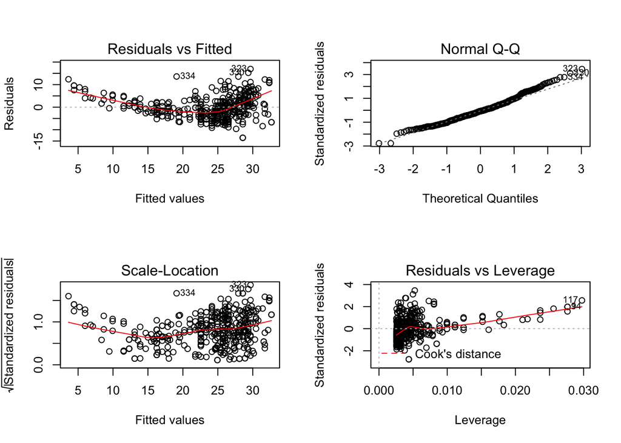

```r
par(mfrow = c(2,2))
plot(lm.fit.auto)
```

```r
set.seed (1)
x <- rnorm (100)
y <- 2*x+rnorm (100)
lm.fit.null.y <- lm(y ~ x + 0)
print_summary <- function(summary){
  coefficients <- summary$coefficients
  paste0("Coefficient(s): ", coefficients[,1], " Standard error(s): ", coefficients[,2], " T Value(s): ",coefficients[,3], " P Value(s): ", coefficients[,4])
}
print_summary(summary(lm.fit.null.y))
```

```
## [1] "Coefficient(s): 1.99387608315844 Standard error(s): 0.106476734499448 T Value(s): 18.7259319374486 P Value(s): 2.64219692500484e-34"
```

```r
lm.fit.null.x <- lm (x ~ y + 0)
print_summary(summary(lm.fit.null.x))
```

```
## [1] "Coefficient(s): 0.391114531478326 Standard error(s): 0.0208862518984257 T Value(s): 18.7259319374486 P Value(s): 2.64219692500473e-34"
```

3. What is the relationship between the results obtained in (a) and (b)? We have the same p-value and t-value. This shows that we are describing the same line, where solving for x in the equation y = 2x + ε means that x = 1/2(y - ε).

```r
lm.fit.x <- lm(x ~ y)
lm.fit.y <- lm(y ~ x)
summary(lm.fit.x)
```

```
##
## Call:
## lm(formula = x ~ y)
##
## Residuals:
##      Min       1Q   Median       3Q      Max
## -0.90848 -0.28101  0.06274  0.24570  0.85736
##
## Coefficients:
##             Estimate Std. Error t value Pr(>|t|)
## (Intercept)  0.03880    0.04266    0.91    0.365
## y            0.38942    0.02099   18.56   <2e-16 ***
## ---
## Signif. codes:  0 '***' 0.001 '**' 0.01 '*' 0.05 '.' 0.1 ' ' 1
##
## Residual standard error: 0.4249 on 98 degrees of freedom
## Multiple R-squared:  0.7784, Adjusted R-squared:  0.7762
## F-statistic: 344.3 on 1 and 98 DF,  p-value: < 2.2e-16
```

```r
summary(lm.fit.y)
```

```
##
## Call:
## lm(formula = y ~ x)
##
## Residuals:
##     Min      1Q  Median      3Q     Max
## -1.8768 -0.6138 -0.1395  0.5394  2.3462
##
## Coefficients:
##             Estimate Std. Error t value Pr(>|t|)
## (Intercept) -0.03769    0.09699  -0.389    0.698
## x            1.99894    0.10773  18.556   <2e-16 ***
## ---
## Signif. codes:  0 '***' 0.001 '**' 0.01 '*' 0.05 '.' 0.1 ' ' 1
##
## Residual standard error: 0.9628 on 98 degrees of freedom
## Multiple R-squared:  0.7784, Adjusted R-squared:  0.7762
## F-statistic: 344.3 on 1 and 98 DF,  p-value: < 2.2e-16
```

```r
set.seed (1)
x1 <- runif (100)
x2 <- 0.5* x1+rnorm (100) /10
y <- 2+2* x1 +0.3* x2+rnorm (100)
```

Y = 2 + 2X1 + 0.3X2 + ε Intercept coefficient = 2 Slope coefficient 1 = 2 Slope 2 coefficient = 0.3

```r
# correlation between x1 and x2
paste0("There's a strong correlation between x1 and x2: ", cor(x1, x2))
```

```
## [1] "There's a strong correlation between x1 and x2: 0.835121242463113"
```

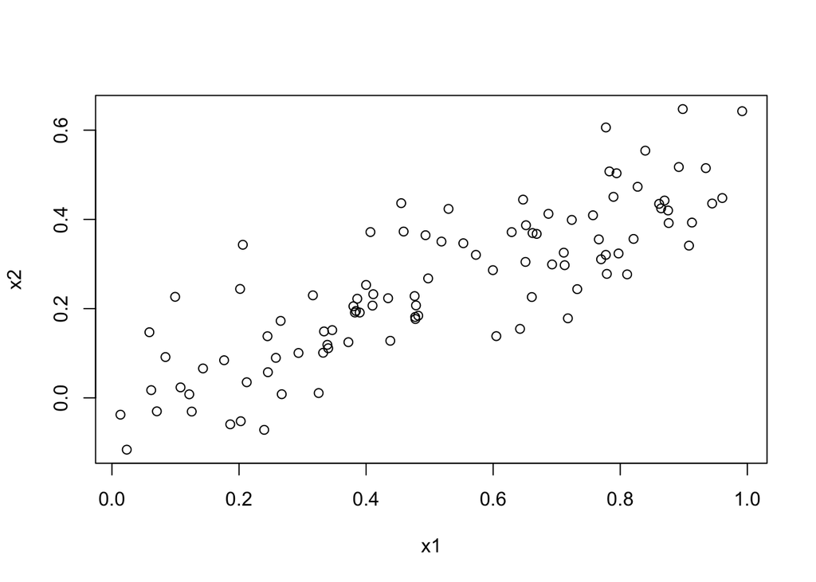

```r
# their scatterplots
plot(x1, x2)
```

c)

```r
# y onto x and x^2
lm.fit.pol <- lm( y ~ x1 + x2)
summary(lm.fit.pol)
```

```
##
## Call:
## lm(formula = y ~ x1 + x2)
##
## Residuals:
##     Min      1Q  Median      3Q     Max
## -2.8311 -0.7273 -0.0537  0.6338  2.3359
##
## Coefficients:
##             Estimate Std. Error t value Pr(>|t|)
## (Intercept)   2.1305     0.2319   9.188 7.61e-15 ***
## x1            1.4396     0.7212   1.996   0.0487 *
## x2            1.0097     1.1337   0.891   0.3754
## ---
## Signif. codes:  0 '***' 0.001 '**' 0.01 '*' 0.05 '.' 0.1 ' ' 1
##
## Residual standard error: 1.056 on 97 degrees of freedom
## Multiple R-squared:  0.2088, Adjusted R-squared:  0.1925
## F-statistic:  12.8 on 2 and 97 DF,  p-value: 1.164e-05
```

The p-value for x1 coefficients is < than 0.05, however the p-value for x2 is not. Therfore, we can reject for β1 but we cannot reject the null hypothesis for β2. d)

```r
lim.fit.pnull <- lm(y ~ x1)
summary(lim.fit.pnull)
```

```
##
## Call:
## lm(formula = y ~ x1)
##
## Residuals:
##      Min       1Q   Median       3Q      Max
## -2.89495 -0.66874 -0.07785  0.59221  2.45560
##
## Coefficients:
##             Estimate Std. Error t value Pr(>|t|)
## (Intercept)   2.1124     0.2307   9.155 8.27e-15 ***
## x1            1.9759     0.3963   4.986 2.66e-06 ***
## ---
## Signif. codes:  0 '***' 0.001 '**' 0.01 '*' 0.05 '.' 0.1 ' ' 1
##
## Residual standard error: 1.055 on 98 degrees of freedom
## Multiple R-squared:  0.2024, Adjusted R-squared:  0.1942
## F-statistic: 24.86 on 1 and 98 DF,  p-value: 2.661e-06
```

Yes, taking a look at the p-values, we can reject it. e)

```r
lim.fit.pnullx2 <- lm(y ~ x2)
summary(lim.fit.pnullx2)
```

```
##
## Call:
## lm(formula = y ~ x2)
##
## Residuals:
##      Min       1Q   Median       3Q      Max
## -2.62687 -0.75156 -0.03598  0.72383  2.44890
##
## Coefficients:
##             Estimate Std. Error t value Pr(>|t|)
## (Intercept)   2.3899     0.1949   12.26  < 2e-16 ***
## x2            2.8996     0.6330    4.58 1.37e-05 ***
## ---
## Signif. codes:  0 '***' 0.001 '**' 0.01 '*' 0.05 '.' 0.1 ' ' 1
##
## Residual standard error: 1.072 on 98 degrees of freedom
## Multiple R-squared:  0.1763, Adjusted R-squared:  0.1679
## F-statistic: 20.98 on 1 and 98 DF,  p-value: 1.366e-05
```

Yes, we can reject.

6. No, they do not contradict each other. As seen in the textbook, the presence of collinearity can mask the importance of a variable and cause the standard error and p-value to increase. In this case, the importance of x2 has been masked.

```r
x1 <- c(x1 , 0.1)
x2 <- c(x2 , 0.8)
y <- c(y,6)

# c to e
lm.fit.pol2 <- lm( y ~ x1 + x2)
summary(lm.fit.pol2)
```

```
##
## Call:
## lm(formula = y ~ x1 + x2)
##
## Residuals:
##      Min       1Q   Median       3Q      Max
## -2.73348 -0.69318 -0.05263  0.66385  2.30619
##
## Coefficients:
##             Estimate Std. Error t value Pr(>|t|)
## (Intercept)   2.2267     0.2314   9.624 7.91e-16 ***
## x1            0.5394     0.5922   0.911  0.36458
## x2            2.5146     0.8977   2.801  0.00614 **
## ---
## Signif. codes:  0 '***' 0.001 '**' 0.01 '*' 0.05 '.' 0.1 ' ' 1
##
## Residual standard error: 1.075 on 98 degrees of freedom
## Multiple R-squared:  0.2188, Adjusted R-squared:  0.2029
## F-statistic: 13.72 on 2 and 98 DF,  p-value: 5.564e-06
```

```r
lm.fit.pnull2 <- lm(y ~ x1)
summary(lm.fit.pnull2)
```

```
##
## Call:
## lm(formula = y ~ x1)
##
## Residuals:
##     Min      1Q  Median      3Q     Max
## -2.8897 -0.6556 -0.0909  0.5682  3.5665
##
## Coefficients:
##             Estimate Std. Error t value Pr(>|t|)
## (Intercept)   2.2569     0.2390   9.445 1.78e-15 ***
## x1            1.7657     0.4124   4.282 4.29e-05 ***
## ---
## Signif. codes:  0 '***' 0.001 '**' 0.01 '*' 0.05 '.' 0.1 ' ' 1
##
## Residual standard error: 1.111 on 99 degrees of freedom
## Multiple R-squared:  0.1562, Adjusted R-squared:  0.1477
## F-statistic: 18.33 on 1 and 99 DF,  p-value: 4.295e-05
```

```r
lm.fit.pnullx22 <- lm(y ~ x2)
summary(lm.fit.pnullx22)
```

```
##
## Call:
## lm(formula = y ~ x2)
##
## Residuals:
##      Min       1Q   Median       3Q      Max
## -2.64729 -0.71021 -0.06899  0.72699  2.38074
##
## Coefficients:
##             Estimate Std. Error t value Pr(>|t|)
## (Intercept)   2.3451     0.1912  12.264  < 2e-16 ***
## x2            3.1190     0.6040   5.164 1.25e-06 ***
## ---
## Signif. codes:  0 '***' 0.001 '**' 0.01 '*' 0.05 '.' 0.1 ' ' 1
##
## Residual standard error: 1.074 on 99 degrees of freedom
## Multiple R-squared:  0.2122, Adjusted R-squared:  0.2042
## F-statistic: 26.66 on 1 and 99 DF,  p-value: 1.253e-06
```

15. 1. predicting per capita crime rate

```r
lm.fit.zn <- lm(crim ~ zn , data = boston)
lm.fit.indus <- lm(crim ~ indus, data = boston)
lm.fit.chas <- lm(crim ~ chas, data = boston)
lm.fit.nox <- lm(crim ~nox, data = boston)
lm.fit.rm <- lm(crim ~ rm, data = boston)
lm.fit.age <- lm(crim ~ age, data = boston)
lm.fit.dis <- lm(crim ~ dis, data = boston)
lm.fit.rad <- lm(crim ~ rad, data = boston)
lm.fit.tax <- lm(crim ~ tax, data = boston)
lm.fit.ptratio <- lm(crim ~ ptratio, data = boston)
lm.fit.black <- lm(crim ~ black, data = boston)
lm.fit.lstat <- lm(crim ~ lstat, data = boston)
lm.fit.medv <- lm(crim ~ medv, data = boston)
print_summary(summary(lm.fit.zn))
```

```
## [1] "Coefficient(s): 4.45369375508638 Standard error(s): 0.417217777789882 T Value(s): 10.6747458813448 P Value(s): 4.03766805048939e-24"
## [2] "Coefficient(s): -0.073934977404123 Standard error(s): 0.0160945961932254 T Value(s): -4.59377647730262 P Value(s): 5.50647210767964e-06"
```

```r
print_summary(summary(lm.fit.indus))
```

```
## [1] "Coefficient(s): -2.0637426063278 Standard error(s): 0.667228297905546 T Value(s): -3.09300821443869 P Value(s): 0.00209126551603981"
## [2] "Coefficient(s): 0.509776331104228 Standard error(s): 0.0510243323317304 T Value(s): 9.99084765656433 P Value(s): 1.45034893302756e-21"
```

```r
print_summary(summary(lm.fit.chas))
```

```
## [1] "Coefficient(s): 3.74444683651805 Standard error(s): 0.396111122353843 T Value(s): 9.45302119836252 P Value(s): 1.23950548474951e-19"
## [2] "Coefficient(s): -1.89277655080378 Standard error(s): 1.50611548365537 T Value(s): -1.25672737007522 P Value(s): 0.209434501535197"
```

```r
print_summary(summary(lm.fit.nox))
```

```
## [1] "Coefficient(s): -13.7198823099743 Standard error(s): 1.69947928103186 T Value(s): -8.07299180584546 P Value(s): 5.07681442622108e-15"
## [2] "Coefficient(s): 31.2485312011229 Standard error(s): 2.99919038061173 T Value(s): 10.4189888721733 P Value(s): 3.7517392603569e-23"
```

```r
print_summary(summary(lm.fit.rm))
```

```
## [1] "Coefficient(s): 20.4818041777924 Standard error(s): 3.3644742107238 T Value(s): 6.08766865042672 P Value(s): 2.27199982890323e-09"
## [2] "Coefficient(s): -2.68405122411395 Standard error(s): 0.532041083377015 T Value(s): -5.04481948476145 P Value(s): 6.34670298468749e-07"
```

```r
print_summary(summary(lm.fit.age))
```

```
## [1] "Coefficient(s): -3.77790631796826 Standard error(s): 0.943984715434622 T Value(s): -4.00208420348084 P Value(s): 7.22171778223826e-05"
## [2] "Coefficient(s): 0.107786227139533 Standard error(s): 0.0127364362587918 T Value(s): 8.46282468262108 P Value(s): 2.85486935024409e-16"
```

```r
print_summary(summary(lm.fit.dis))
```

```
## [1] "Coefficient(s): 9.49926164655728 Standard error(s): 0.730397199379293 T Value(s): 13.0056107206188 P Value(s): 1.50274785019168e-33"
## [2] "Coefficient(s): -1.5509016824101 Standard error(s): 0.168330030929704 T Value(s): -9.21345807307415 P Value(s): 8.5199487669261e-19"
```

```r
print_summary(summary(lm.fit.rad))
```

```
## [1] "Coefficient(s): -2.28715944831038 Standard error(s): 0.443475833759636 T Value(s): -5.15734855024822 P Value(s): 3.60584616355712e-07"
## [2] "Coefficient(s): 0.617910927327201 Standard error(s): 0.0343318196678424 T Value(s): 17.998199143111 P Value(s): 2.69384439818633e-56"
```

```r
print_summary(summary(lm.fit.tax))
```

```
## [1] "Coefficient(s): -8.52836909306913 Standard error(s): 0.815809391645573 T Value(s): -10.4538746187593 P Value(s): 2.77360048809739e-23"
## [2] "Coefficient(s): 0.0297422528227653 Standard error(s): 0.00184741511910325 T Value(s): 16.0993880125884 P Value(s): 2.35712683525685e-47"
```

```r
print_summary(summary(lm.fit.ptratio))
```

```
## [1] "Coefficient(s): -17.6469334724482 Standard error(s): 3.14727179816026 T Value(s): -5.60705735131097 P Value(s): 3.39525491479262e-08"
## [2] "Coefficient(s): 1.15198278707059 Standard error(s): 0.169373609252715 T Value(s): 6.80143023552017 P Value(s): 2.94292244735967e-11"
```

```r
print_summary(summary(lm.fit.black))
```

```
## [1] "Coefficient(s): 16.5535292242067 Standard error(s): 1.42590275488633 T Value(s): 11.6091571935607 P Value(s): 8.92223925160907e-28"
## [2] "Coefficient(s): -0.0362796405673308 Standard error(s): 0.00387315383170155 T Value(s): -9.36695058956449 P Value(s): 2.48727397377375e-19"
```

```r
print_summary(summary(lm.fit.lstat))
```

```
## [1] "Coefficient(s): -3.33053805714505 Standard error(s): 0.693758294039539 T Value(s): -4.80071818349351 P Value(s): 2.08702177381758e-06"
## [2] "Coefficient(s): 0.548804782062398 Standard error(s): 0.0477609709441814 T Value(s): 11.490653795623 P Value(s): 2.65427723147327e-27"
```

```r
print_summary(summary(lm.fit.medv))
```

```
## [1] "Coefficient(s): 11.7965357502219 Standard error(s): 0.934189161731609 T Value(s): 12.6275664859523 P Value(s): 5.93411886867812e-32"
## [2] "Coefficient(s): -0.363159922257603 Standard error(s): 0.0383901746742235 T Value(s): -9.45971007788721 P Value(s): 1.17398708219449e-19"
```

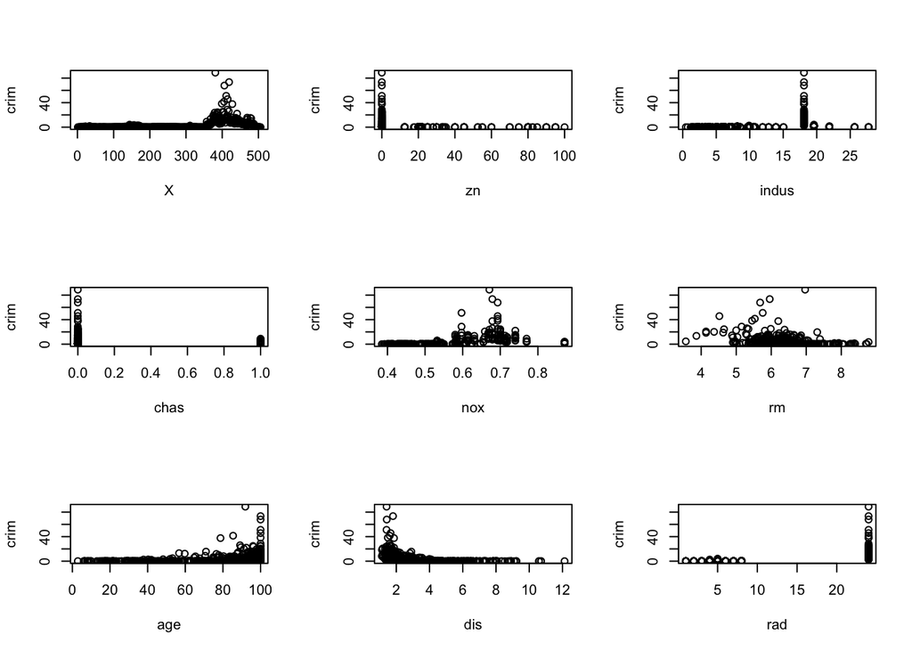

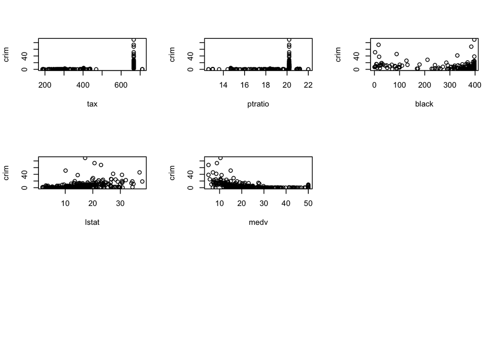

```r
par(mfrow = c(3,3))
plot(crim ~ .-crim, data = boston)
```

You can see from the summary and the plots that ‘chas’ is not as related to crime rates as other predictors. b)

```r
# multiple regression model
lm.fit.mr <- lm(crim ~ ., data = boston)
summary(lm.fit.mr)
```

```
##
## Call:
## lm(formula = crim ~ ., data = boston)
##
## Residuals:
##    Min     1Q Median     3Q    Max
## -9.854 -2.164 -0.363  0.993 74.935
##
## Coefficients:
##               Estimate Std. Error t value Pr(>|t|)
## (Intercept)  1.709e+01  7.240e+00   2.361 0.018616 *
## X           -1.672e-03  2.828e-03  -0.591 0.554672
## zn           4.598e-02  1.884e-02   2.440 0.015030 *
## indus       -6.418e-02  8.346e-02  -0.769 0.442269
## chas        -7.310e-01  1.181e+00  -0.619 0.536327
## nox         -1.019e+01  5.283e+00  -1.929 0.054269 .
## rm           4.568e-01  6.149e-01   0.743 0.457889
## age         -2.893e-04  1.818e-02  -0.016 0.987310
## dis         -1.001e+00  2.830e-01  -3.538 0.000442 ***
## rad          6.009e-01  9.068e-02   6.626 9.07e-11 ***
## tax         -3.314e-03  5.219e-03  -0.635 0.525733
## ptratio     -2.696e-01  1.866e-01  -1.445 0.149092
## black       -7.484e-03  3.677e-03  -2.035 0.042347 *
## lstat        1.241e-01  7.586e-02   1.636 0.102379
## medv        -2.007e-01  6.064e-02  -3.310 0.001000 **
## ---
## Signif. codes:  0 '***' 0.001 '**' 0.01 '*' 0.05 '.' 0.1 ' ' 1
##
## Residual standard error: 6.443 on 491 degrees of freedom
## Multiple R-squared:  0.4544, Adjusted R-squared:  0.4388
## F-statistic: 29.21 on 14 and 491 DF,  p-value: < 2.2e-16
```

We reject zn, dis, rad, black, and medv. All their p-values are less than 0.05. c)

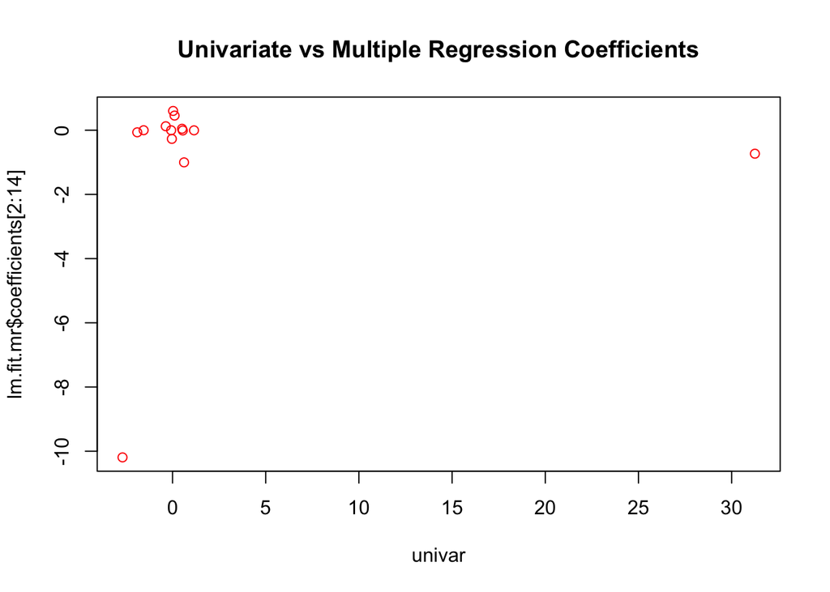

```r
univar <- lm.fit.zn$coefficients[2]
univar <- append(univar, lm.fit.indus$coefficients[2])
univar <- append(univar, lm.fit.chas$coefficients[2])
univar <- append(univar, lm.fit.nox$coefficients[2])
univar <- append(univar, lm.fit.rm$coefficients[2])
univar <- append(univar, lm.fit.age$coefficients[2])
univar <- append(univar, lm.fit.dis$coefficients[2])
univar <- append(univar, lm.fit.rad$coefficients[2])
univar <- append(univar, lm.fit.tax$coefficients[2])
univar <- append(univar, lm.fit.ptratio$coefficients[2])
univar <- append(univar, lm.fit.black$coefficients[2])
univar <- append(univar, lm.fit.lstat$coefficients[2])

univar <- append(univar, lm.fit.medv$coefficients[2])
plot(univar, lm.fit.mr$coefficients[2:14], main = "Univariate vs Multiple Regression Coefficients", col = 2)
```

Clearly, there is a difference between univariate and multi regression coefficients. The linear regression model often ignores the regression coefficients for other predictors. In multiple regression, we can say that the slopes of predictors represent an average effect while holding other predictors fixed.

```r
lm.fit.zn.poly <- lm(crim ~ poly(zn, 3) , data = boston)
lm.fit.indus.poly <- lm(crim ~ poly(indus, 3), data = boston)
lm.fit.nox.poly <- lm(crim ~ poly(nox,3),  data = boston)
lm.fit.rm.poly <- lm(crim ~ poly(rm, 3),  data = boston)
lm.fit.age.poly <- lm(crim ~ poly(age, 3), data = boston)
lm.fit.dis.poly <- lm(crim ~ poly(dis, 3),  data = boston)
lm.fit.rad.poly <- lm(crim ~ poly(rad,3), data = boston)
lm.fit.tax.poly <- lm(crim ~ poly(tax,3), data = boston)
lm.fit.ptratio.poly <- lm(crim ~ poly(ptratio,3), data = boston)
lm.fit.black.poly <- lm(crim ~ poly(black,3), data = boston)
lm.fit.lstat.poly <- lm(crim ~ poly(lstat,3), data = boston)
lm.fit.medv.poly <- lm(crim ~ poly(medv,3), data = boston)
summary(lm.fit.zn.poly)
```

```
##
## Call:
## lm(formula = crim ~ poly(zn, 3), data = boston)
##
## Residuals:
##    Min     1Q Median     3Q    Max
## -4.821 -4.614 -1.294  0.473 84.130
##
## Coefficients:
##              Estimate Std. Error t value Pr(>|t|)
## (Intercept)    3.6135     0.3722   9.709  < 2e-16 ***
## poly(zn, 3)1 -38.7498     8.3722  -4.628  4.7e-06 ***
## poly(zn, 3)2  23.9398     8.3722   2.859  0.00442 **
## poly(zn, 3)3 -10.0719     8.3722  -1.203  0.22954
## ---
## Signif. codes:  0 '***' 0.001 '**' 0.01 '*' 0.05 '.' 0.1 ' ' 1
##
## Residual standard error: 8.372 on 502 degrees of freedom
## Multiple R-squared:  0.05824,    Adjusted R-squared:  0.05261
## F-statistic: 10.35 on 3 and 502 DF,  p-value: 1.281e-06
```

```r
summary(lm.fit.indus.poly)
```

```
##
## Call:
## lm(formula = crim ~ poly(indus, 3), data = boston)
##
## Residuals:
##    Min     1Q Median     3Q    Max
## -8.278 -2.514  0.054  0.764 79.713
##
## Coefficients:
##                 Estimate Std. Error t value Pr(>|t|)
## (Intercept)        3.614      0.330  10.950  < 2e-16 ***
## poly(indus, 3)1   78.591      7.423  10.587  < 2e-16 ***
## poly(indus, 3)2  -24.395      7.423  -3.286  0.00109 **
## poly(indus, 3)3  -54.130      7.423  -7.292  1.2e-12 ***
## ---
## Signif. codes:  0 '***' 0.001 '**' 0.01 '*' 0.05 '.' 0.1 ' ' 1
##
## Residual standard error: 7.423 on 502 degrees of freedom
## Multiple R-squared:  0.2597, Adjusted R-squared:  0.2552
## F-statistic: 58.69 on 3 and 502 DF,  p-value: < 2.2e-16
```

```r
summary(lm.fit.nox.poly)
```

```
##
## Call:
## lm(formula = crim ~ poly(nox, 3), data = boston)
##
## Residuals:
##    Min     1Q Median     3Q    Max
## -9.110 -2.068 -0.255  0.739 78.302
##
## Coefficients:
##               Estimate Std. Error t value Pr(>|t|)
## (Intercept)     3.6135     0.3216  11.237  < 2e-16 ***
## poly(nox, 3)1  81.3720     7.2336  11.249  < 2e-16 ***
## poly(nox, 3)2 -28.8286     7.2336  -3.985 7.74e-05 ***
## poly(nox, 3)3 -60.3619     7.2336  -8.345 6.96e-16 ***
## ---
## Signif. codes:  0 '***' 0.001 '**' 0.01 '*' 0.05 '.' 0.1 ' ' 1
##
## Residual standard error: 7.234 on 502 degrees of freedom
## Multiple R-squared:  0.297,  Adjusted R-squared:  0.2928
## F-statistic: 70.69 on 3 and 502 DF,  p-value: < 2.2e-16
```

```r
summary(lm.fit.rm.poly)
```

```
##
## Call:
## lm(formula = crim ~ poly(rm, 3), data = boston)
##
## Residuals:
##     Min      1Q  Median      3Q     Max
## -18.485  -3.468  -2.221  -0.015  87.219
##
## Coefficients:
##              Estimate Std. Error t value Pr(>|t|)
## (Intercept)    3.6135     0.3703   9.758  < 2e-16 ***
## poly(rm, 3)1 -42.3794     8.3297  -5.088 5.13e-07 ***
## poly(rm, 3)2  26.5768     8.3297   3.191  0.00151 **
## poly(rm, 3)3  -5.5103     8.3297  -0.662  0.50858
## ---
## Signif. codes:  0 '***' 0.001 '**' 0.01 '*' 0.05 '.' 0.1 ' ' 1
##
## Residual standard error: 8.33 on 502 degrees of freedom
## Multiple R-squared:  0.06779,    Adjusted R-squared:  0.06222
## F-statistic: 12.17 on 3 and 502 DF,  p-value: 1.067e-07
```

```r
summary(lm.fit.age.poly)
```

```
##
## Call:
## lm(formula = crim ~ poly(age, 3), data = boston)
##
## Residuals:
##    Min     1Q Median     3Q    Max
## -9.762 -2.673 -0.516  0.019 82.842
##
## Coefficients:
##               Estimate Std. Error t value Pr(>|t|)
## (Intercept)     3.6135     0.3485  10.368  < 2e-16 ***
## poly(age, 3)1  68.1820     7.8397   8.697  < 2e-16 ***
## poly(age, 3)2  37.4845     7.8397   4.781 2.29e-06 ***
## poly(age, 3)3  21.3532     7.8397   2.724  0.00668 **
## ---
## Signif. codes:  0 '***' 0.001 '**' 0.01 '*' 0.05 '.' 0.1 ' ' 1
##
## Residual standard error: 7.84 on 502 degrees of freedom
## Multiple R-squared:  0.1742, Adjusted R-squared:  0.1693
## F-statistic: 35.31 on 3 and 502 DF,  p-value: < 2.2e-16
```

```r
summary(lm.fit.dis.poly)
```

```
##
## Call:
## lm(formula = crim ~ poly(dis, 3), data = boston)
##
## Residuals:
##     Min      1Q  Median      3Q     Max
## -10.757  -2.588   0.031   1.267  76.378
##
## Coefficients:
##               Estimate Std. Error t value Pr(>|t|)
## (Intercept)     3.6135     0.3259  11.087  < 2e-16 ***
## poly(dis, 3)1 -73.3886     7.3315 -10.010  < 2e-16 ***
## poly(dis, 3)2  56.3730     7.3315   7.689 7.87e-14 ***
## poly(dis, 3)3 -42.6219     7.3315  -5.814 1.09e-08 ***
## ---
## Signif. codes:  0 '***' 0.001 '**' 0.01 '*' 0.05 '.' 0.1 ' ' 1
##
## Residual standard error: 7.331 on 502 degrees of freedom
## Multiple R-squared:  0.2778, Adjusted R-squared:  0.2735
## F-statistic: 64.37 on 3 and 502 DF,  p-value: < 2.2e-16
```

```r
summary(lm.fit.rad.poly)
```

```
##
## Call:
## lm(formula = crim ~ poly(rad, 3), data = boston)
##
## Residuals:
##     Min      1Q  Median      3Q     Max
## -10.381  -0.412  -0.269   0.179  76.217
##
## Coefficients:
##               Estimate Std. Error t value Pr(>|t|)
## (Intercept)     3.6135     0.2971  12.164  < 2e-16 ***
## poly(rad, 3)1 120.9074     6.6824  18.093  < 2e-16 ***
## poly(rad, 3)2  17.4923     6.6824   2.618  0.00912 **
## poly(rad, 3)3   4.6985     6.6824   0.703  0.48231
## ---
## Signif. codes:  0 '***' 0.001 '**' 0.01 '*' 0.05 '.' 0.1 ' ' 1
##
## Residual standard error: 6.682 on 502 degrees of freedom
## Multiple R-squared:    0.4,  Adjusted R-squared:  0.3965
## F-statistic: 111.6 on 3 and 502 DF,  p-value: < 2.2e-16
```

```r
summary(lm.fit.tax.poly)
```

```
##
## Call:
## lm(formula = crim ~ poly(tax, 3), data = boston)
##
## Residuals:
##     Min      1Q  Median      3Q     Max
## -13.273  -1.389   0.046   0.536  76.950
##
## Coefficients:
##               Estimate Std. Error t value Pr(>|t|)
## (Intercept)     3.6135     0.3047  11.860  < 2e-16 ***
## poly(tax, 3)1 112.6458     6.8537  16.436  < 2e-16 ***
## poly(tax, 3)2  32.0873     6.8537   4.682 3.67e-06 ***
## poly(tax, 3)3  -7.9968     6.8537  -1.167    0.244
## ---
## Signif. codes:  0 '***' 0.001 '**' 0.01 '*' 0.05 '.' 0.1 ' ' 1
##
## Residual standard error: 6.854 on 502 degrees of freedom
## Multiple R-squared:  0.3689, Adjusted R-squared:  0.3651
## F-statistic:  97.8 on 3 and 502 DF,  p-value: < 2.2e-16
```

```r
summary(lm.fit.ptratio.poly)
```

```
##
## Call:
## lm(formula = crim ~ poly(ptratio, 3), data = boston)
##
## Residuals:
##    Min     1Q Median     3Q    Max
## -6.833 -4.146 -1.655  1.408 82.697
##
## Coefficients:
##                   Estimate Std. Error t value Pr(>|t|)
## (Intercept)          3.614      0.361  10.008  < 2e-16 ***
## poly(ptratio, 3)1   56.045      8.122   6.901 1.57e-11 ***
## poly(ptratio, 3)2   24.775      8.122   3.050  0.00241 **
## poly(ptratio, 3)3  -22.280      8.122  -2.743  0.00630 **
## ---
## Signif. codes:  0 '***' 0.001 '**' 0.01 '*' 0.05 '.' 0.1 ' ' 1
##
## Residual standard error: 8.122 on 502 degrees of freedom
## Multiple R-squared:  0.1138, Adjusted R-squared:  0.1085
## F-statistic: 21.48 on 3 and 502 DF,  p-value: 4.171e-13
```

```r
summary(lm.fit.black.poly)
```

```
##
## Call:
## lm(formula = crim ~ poly(black, 3), data = boston)
##
## Residuals:
##     Min      1Q  Median      3Q     Max
## -13.096  -2.343  -2.128  -1.439  86.790
##
## Coefficients:
##                 Estimate Std. Error t value Pr(>|t|)
## (Intercept)       3.6135     0.3536  10.218   <2e-16 ***
## poly(black, 3)1 -74.4312     7.9546  -9.357   <2e-16 ***
## poly(black, 3)2   5.9264     7.9546   0.745    0.457
## poly(black, 3)3  -4.8346     7.9546  -0.608    0.544
## ---
## Signif. codes:  0 '***' 0.001 '**' 0.01 '*' 0.05 '.' 0.1 ' ' 1
##
## Residual standard error: 7.955 on 502 degrees of freedom
## Multiple R-squared:  0.1498, Adjusted R-squared:  0.1448
## F-statistic: 29.49 on 3 and 502 DF,  p-value: < 2.2e-16
```

```r
summary(lm.fit.lstat.poly)
```

```
##
## Call:
## lm(formula = crim ~ poly(lstat, 3), data = boston)
##
## Residuals:
##     Min      1Q  Median      3Q     Max
## -15.234  -2.151  -0.486   0.066  83.353
##
## Coefficients:
##                 Estimate Std. Error t value Pr(>|t|)
## (Intercept)       3.6135     0.3392  10.654   <2e-16 ***
## poly(lstat, 3)1  88.0697     7.6294  11.543   <2e-16 ***
## poly(lstat, 3)2  15.8882     7.6294   2.082   0.0378 *
## poly(lstat, 3)3 -11.5740     7.6294  -1.517   0.1299
## ---
## Signif. codes:  0 '***' 0.001 '**' 0.01 '*' 0.05 '.' 0.1 ' ' 1
##
## Residual standard error: 7.629 on 502 degrees of freedom
## Multiple R-squared:  0.2179, Adjusted R-squared:  0.2133
## F-statistic: 46.63 on 3 and 502 DF,  p-value: < 2.2e-16
```

```r
summary(lm.fit.medv.poly)
```

```
##
## Call:
## lm(formula = crim ~ poly(medv, 3), data = boston)
##
## Residuals:
##     Min      1Q  Median      3Q     Max
## -24.427  -1.976  -0.437   0.439  73.655
##
## Coefficients:
##                Estimate Std. Error t value Pr(>|t|)
## (Intercept)       3.614      0.292  12.374  < 2e-16 ***
## poly(medv, 3)1  -75.058      6.569 -11.426  < 2e-16 ***
## poly(medv, 3)2   88.086      6.569  13.409  < 2e-16 ***
## poly(medv, 3)3  -48.033      6.569  -7.312 1.05e-12 ***
## ---
## Signif. codes:  0 '***' 0.001 '**' 0.01 '*' 0.05 '.' 0.1 ' ' 1
##
## Residual standard error: 6.569 on 502 degrees of freedom
## Multiple R-squared:  0.4202, Adjusted R-squared:  0.4167
## F-statistic: 121.3 on 3 and 502 DF,  p-value: < 2.2e-16
```